# R Notebook

Week 10 Day 4

Elements of model building: Exploratory data analysis Feature engineering Feature selection Model development Manual / automatic model building Manual tools: ggpairs, anova, r2, p, coplots, residual plots

# Overfitting

| gender | name | surname | job_area | salary | age | retired | location | savings |
| --- | --- | --- | --- | --- | --- | --- | --- | --- |
| Female | Jools | Williamson | Legal | 19000 | 41 | No | Shetland | 33451 |
| Male | Jimmy | Laurenceso | Product Management | 21000 | 78 | Yes | Edinburgh | 27308 |
| Male | Freddy | Irvine | Human Resources | 18000 | 31 | No | Inverness | 37337 |
| Male | Jimmy | Tait | Sales | 19000 | 90 | Yes | Edinburgh | 15699 |
| Female | India | Sinclair | Product Management | 23000 | 19 | No | Shetland | 46726 |
| Male | Jimmy | Laurenceso | Human Resources | 25000 | 20 | No | Aberdeen | 38405 |
| Female | Helena | Jamieson | Training | 11000 | 32 | No | Glasgow | 49070 |
| Female | Helena | Galdie | Legal | 18000 | 60 | No | Inverness | 40517 |
| Male | Charles | Nicolson | Product Management | 23000 | 69 | Yes | Aberdeen | 16894 |
| Male | Gord | Fraser | Sales | 24000 | 39 | No | Orkney | 22508 |

[output cut: 990 more lines]

```r
model_overfit <- lm(savings ~ ., data = savings)

model_wellfit <- lm(savings ~ salary + age + retired, data = savings)

model_underfit <- lm(savings ~ salary, data = savings)
```

```r
summary(model_overfit)
```

```
Call:
lm(formula = savings ~ ., data = savings)

Residuals:
   Min     1Q Median     3Q    Max
-27670  -6563   -188   6167  35227

Coefficients: (1 not defined because of singularities)
                             Estimate Std. Error t value Pr(>|t|)
(Intercept)                 2.372e+04  2.442e+03   9.713  < 2e-16 ***
genderMale                  3.371e+02  1.708e+03   0.197  0.84358
nameAngus                  -1.345e+03  1.747e+03  -0.770  0.44162
nameBert                   -6.908e+02  1.696e+03  -0.407  0.68381
nameBonnie                  1.601e+03  1.686e+03   0.950  0.34247
nameCara                    1.247e+03  1.741e+03   0.716  0.47402
nameCharles                 4.416e+01  1.711e+03   0.026  0.97941
nameDonald                  2.381e+03  1.910e+03   1.246  0.21291
nameDora                   -1.814e+03  1.742e+03  -1.042  0.29785
nameEd                      2.710e+03  1.780e+03   1.523  0.12812
nameEmmy                    2.105e+03  1.699e+03   1.239  0.21547
nameFlorence                1.466e+03  1.713e+03   0.856  0.39227
nameFreddy                  2.080e+02  1.695e+03   0.123  0.90239
nameGilly                  -7.143e+02  1.802e+03  -0.396  0.69191
nameGord                   -6.295e+02  1.821e+03  -0.346  0.72965
nameHarry                   2.188e+02  1.785e+03   0.123  0.90249
nameHelena                  1.284e+03  1.753e+03   0.732  0.46416
nameIndia                   2.854e+03  1.785e+03   1.599  0.11020
nameIvan                    1.210e+03  1.893e+03   0.639  0.52286
nameJimmy                          NA         NA      NA       NA
nameJools                  -6.668e+02  1.699e+03  -0.392  0.69484
surnameFraser              -3.660e+03  1.875e+03  -1.952  0.05122 .
surnameGaldie              -1.706e+03  1.826e+03  -0.934  0.35037
surnameHalcrow             -1.636e+03  1.728e+03  -0.947  0.34380
surnameHenderson           -2.878e+03  1.728e+03  -1.665  0.09614 .
surnameIrvine              -1.554e+03  1.698e+03  -0.915  0.36043
surnameJamieson            -4.087e+03  1.795e+03  -2.276  0.02301 *
surnameJohnson             -5.021e+03  1.806e+03  -2.780  0.00552 **
surnameLaurenceso          -3.387e+03  1.773e+03  -1.910  0.05637 .
surnameLeask               -1.332e+03  1.727e+03  -0.771  0.44070
surnameManson              -4.294e+03  1.807e+03  -2.376  0.01767 *
```

[output cut: 14 more lines]

```
age                         1.579e+02  2.397e+01   6.590 6.68e-11 ***
retiredYes                 -1.956e+04  1.070e+03 -18.288  < 2e-16 ***
locationEdinburgh           1.434e+03  1.127e+03   1.273  0.20339
locationGlasgow             2.753e+03  1.183e+03   2.327  0.02016 *
locationInverness           8.503e+02  1.195e+03   0.711  0.47695
locationOrkney              9.116e+02  1.122e+03   0.813  0.41656
locationShetland            2.284e+03  1.152e+03   1.982  0.04770 *
locationStirling            1.559e+03  1.136e+03   1.372  0.17018
locationWestern Isles       1.290e+03  1.121e+03   1.151  0.24990
---
Signif. codes:  0 ‘***’ 0.001 ‘**’ 0.01 ‘*’ 0.05 ‘.’ 0.1 ‘ ’ 1

Residual standard error: 9634 on 1147 degrees of freedom
Multiple R-squared:  0.3715,    Adjusted R-squared:  0.343
F-statistic: 13.04 on 52 and 1147 DF,  p-value: < 2.2e-16
```

```r
summary(model_underfit)
```

```
Call:
lm(formula = savings ~ salary, data = savings)

Residuals:
   Min     1Q Median     3Q    Max
-38662  -7640     53   8231  35808

Coefficients:
             Estimate Std. Error t value Pr(>|t|)
(Intercept) 2.477e+04  1.525e+03  16.243  < 2e-16 ***
salary      4.846e-01  7.506e-02   6.456 1.56e-10 ***
---
Signif. codes:  0 ‘***’ 0.001 ‘**’ 0.01 ‘*’ 0.05 ‘.’ 0.1 ‘ ’ 1

Residual standard error: 11690 on 1198 degrees of freedom
Multiple R-squared:  0.03362,   Adjusted R-squared:  0.03281
F-statistic: 41.68 on 1 and 1198 DF,  p-value: 1.56e-10
```

```r
summary(model_wellfit)
```

```
Call:
lm(formula = savings ~ salary + age + retired, data = savings)

Residuals:
   Min     1Q Median     3Q    Max
-28659  -6968    -59   6410  39736

Coefficients:
              Estimate Std. Error t value Pr(>|t|)
(Intercept)  2.227e+04  1.604e+03  13.882  < 2e-16 ***
salary       4.854e-01  6.207e-02   7.820 1.15e-14 ***
age          1.600e+02  2.351e+01   6.806 1.59e-11 ***
retiredYes  -1.959e+04  1.052e+03 -18.612  < 2e-16 ***
---
Signif. codes:  0 ‘***’ 0.001 ‘**’ 0.01 ‘*’ 0.05 ‘.’ 0.1 ‘ ’ 1

Residual standard error: 9665 on 1196 degrees of freedom
Multiple R-squared:  0.3403,    Adjusted R-squared:  0.3387
F-statistic: 205.7 on 3 and 1196 DF,  p-value: < 2.2e-16
```

Parsimonious measure of goodness of fit

A parsimonious model is one which includes as few variables as necessary Tools to help with this are: Adjusted r-squared - measured the proportion of the variation in your response variable Akaike information criterion (AIC) - a single number scro used to determine which of the model is most likely the best model Bayes Information Criterion (BIC) - Measure of goodness of fit

R-squared - larger values is better AIC and BIC - lower values are better

BIC tends to be more parsimonious. (It tends to select smaller models) - BIC penalises larger models when compared to AIC

Evaluating model by these values

```r
summary(model_overfit)
```

```
Call:
lm(formula = savings ~ ., data = savings)

Residuals:
   Min     1Q Median     3Q    Max
-27670  -6563   -188   6167  35227

Coefficients: (1 not defined because of singularities)
                             Estimate Std. Error t value Pr(>|t|)
(Intercept)                 2.372e+04  2.442e+03   9.713  < 2e-16 ***
genderMale                  3.371e+02  1.708e+03   0.197  0.84358
nameAngus                  -1.345e+03  1.747e+03  -0.770  0.44162
nameBert                   -6.908e+02  1.696e+03  -0.407  0.68381
nameBonnie                  1.601e+03  1.686e+03   0.950  0.34247
nameCara                    1.247e+03  1.741e+03   0.716  0.47402
nameCharles                 4.416e+01  1.711e+03   0.026  0.97941
nameDonald                  2.381e+03  1.910e+03   1.246  0.21291
nameDora                   -1.814e+03  1.742e+03  -1.042  0.29785
nameEd                      2.710e+03  1.780e+03   1.523  0.12812
nameEmmy                    2.105e+03  1.699e+03   1.239  0.21547
nameFlorence                1.466e+03  1.713e+03   0.856  0.39227
nameFreddy                  2.080e+02  1.695e+03   0.123  0.90239
nameGilly                  -7.143e+02  1.802e+03  -0.396  0.69191
nameGord                   -6.295e+02  1.821e+03  -0.346  0.72965
nameHarry                   2.188e+02  1.785e+03   0.123  0.90249
nameHelena                  1.284e+03  1.753e+03   0.732  0.46416
nameIndia                   2.854e+03  1.785e+03   1.599  0.11020
nameIvan                    1.210e+03  1.893e+03   0.639  0.52286
nameJimmy                          NA         NA      NA       NA
nameJools                  -6.668e+02  1.699e+03  -0.392  0.69484
surnameFraser              -3.660e+03  1.875e+03  -1.952  0.05122 .
surnameGaldie              -1.706e+03  1.826e+03  -0.934  0.35037
surnameHalcrow             -1.636e+03  1.728e+03  -0.947  0.34380
surnameHenderson           -2.878e+03  1.728e+03  -1.665  0.09614 .
surnameIrvine              -1.554e+03  1.698e+03  -0.915  0.36043
surnameJamieson            -4.087e+03  1.795e+03  -2.276  0.02301 *
surnameJohnson             -5.021e+03  1.806e+03  -2.780  0.00552 **
surnameLaurenceso          -3.387e+03  1.773e+03  -1.910  0.05637 .
surnameLeask               -1.332e+03  1.727e+03  -0.771  0.44070
surnameManson              -4.294e+03  1.807e+03  -2.376  0.01767 *
```

[output cut: 14 more lines]

```
age                         1.579e+02  2.397e+01   6.590 6.68e-11 ***
retiredYes                 -1.956e+04  1.070e+03 -18.288  < 2e-16 ***
locationEdinburgh           1.434e+03  1.127e+03   1.273  0.20339
locationGlasgow             2.753e+03  1.183e+03   2.327  0.02016 *
locationInverness           8.503e+02  1.195e+03   0.711  0.47695
locationOrkney              9.116e+02  1.122e+03   0.813  0.41656
locationShetland            2.284e+03  1.152e+03   1.982  0.04770 *
locationStirling            1.559e+03  1.136e+03   1.372  0.17018
locationWestern Isles       1.290e+03  1.121e+03   1.151  0.24990
---
Signif. codes:  0 ‘***’ 0.001 ‘**’ 0.01 ‘*’ 0.05 ‘.’ 0.1 ‘ ’ 1

Residual standard error: 9634 on 1147 degrees of freedom
Multiple R-squared:  0.3715,    Adjusted R-squared:  0.343
F-statistic: 13.04 on 52 and 1147 DF,  p-value: < 2.2e-16
```

```r
summary(model_overfit)$adj.r.squared
```

```
[1] 0.3429625
```

```r
AIC(model_overfit)
```

```
[1] 25474.46
```

```r
BIC(model_overfit)
```

```
[1] 25749.33
```

| r.squared | adj.r.squared | sigma | statistic | p.value | df | logLik | AIC | BIC | deviance | df.residual | nobs |
| --- | --- | --- | --- | --- | --- | --- | --- | --- | --- | --- | --- |
| 0.3714579 | 0.3429625 | 9633.547 | 13.03573 | 4.373571e-83 | 52 | -12683.23 | 25474.46 | 25749.33 | 106447586521 | 1147 | 1200 |

Task: Find the R-squared, adjusted R-squared, AIC and BIC score for: The well fitted model The over fitted model The under-fitted model

Does the results you found match with your expectations?

| r.squared | adj.r.squared | sigma | statistic | p.value | df | logLik | AIC | BIC | deviance | df.residual | nobs |
| --- | --- | --- | --- | --- | --- | --- | --- | --- | --- | --- | --- |
| 0.03361997 | 0.0328133 | 11688.16 | 41.67793 | 1.55991e-10 | 1 | -12941.32 | 25888.65 | 25903.92 | 163662583678 | 1198 | 1200 |

```r
broom::glance(model_underfit)


AIC(model_underfit)
```

```
[1] 25888.65
```

```r
BIC(model_underfit)
```

```
[1] 25903.92
```

```r
summary(model_underfit)$adj.r.squared
```

```
[1] 0.0328133
```

| r.squared | adj.r.squared | sigma | statistic | p.value | df | logLik | AIC | BIC | deviance | df.residual | nobs |
| --- | --- | --- | --- | --- | --- | --- | --- | --- | --- | --- | --- |
| 0.3403172 | 0.3386625 | 9665.019 | 205.6642 | 1.479567e-107 | 3 | -12712.24 | 25434.49 | 25459.94 | 111721457932 | 1196 | 1200 |

```r
broom::glance(model_wellfit)


AIC(model_wellfit)
```

```
[1] 25434.49
```

```r
BIC(model_wellfit)
```

```
[1] 25459.94
```

```r
summary(model_wellfit)$adj.r.squared
```

```
[1] 0.3386625
```

## Test and training set

Sits in between feature selection and model development

```r
set.seed(9)

# count rows
n_data <- nrow(savings)

# make test index
test_index <- sample(1:n_data, size = n_data * 0.2)

# use test index to create test and training split

test <- slice(savings, test_index)
train <- slice(savings, -test_index)
```

```r
model <- lm(savings ~ salary + age + retired, data = train)
```

```r
library(modelr)
```

```r
predictions_test <- test %>%
  add_predictions(model) %>%
  select(savings, pred)

predictions_test
```

| savings | pred |
| --- | --- |
| 49585 | 45678.48 |
| 20587 | 21785.43 |
| 21653 | 34415.48 |
| 38131 | 37119.74 |
| 26602 | 20783.73 |
| 38697 | 23328.70 |
| 15305 | 20072.29 |
| 45999 | 35325.15 |
| 41128 | 38648.83 |
| 11785 | 21509.36 |

[output cut: 230 more lines]

```r
# calculate mean square errors
mse_test <- mean((predictions_test$pred - test$savings)**2)
mse_test
```

```
[1] 103801411
```

Calculate the mean squared error between predicted savings and actual savings in the training dataset. Which is higher, the error on the test or the error on the training data? Is this what you would expect?

```r
mse_train
```

```
[1] 90588910
```

the mean squared error is smaller - so what does this mean? It is better at predicting the data in the training set, than in the test set. Which makes sense, because this is the data that trained it

Test-train split is one way of evaluating a model, and K-Fold cross validation is another.

# K-fold cross validation

```r
library(caret)
cv_10_fold <- trainControl(method = "cv",
                           number = 10,
                           savePredictions = TRUE)

model <- train(savings ~ salary + age + retired,
               data = savings,
               trControl = cv_10_fold,
               method = "lm")
```

| pred | obs | rowIndex | intercept | Resample |
| --- | --- | --- | --- | --- |
| 36648.27 | 42582 | 20 | TRUE | Fold01 |
| 35924.56 | 11045 | 24 | TRUE | Fold01 |
| 42712.58 | 47226 | 26 | TRUE | Fold01 |
| 45083.41 | 40656 | 29 | TRUE | Fold01 |
| 39755.35 | 51970 | 68 | TRUE | Fold01 |
| 34302.42 | 30053 | 73 | TRUE | Fold01 |
| 43860.53 | 50943 | 76 | TRUE | Fold01 |
| 35587.68 | 45058 | 83 | TRUE | Fold01 |
| 43336.51 | 33599 | 87 | TRUE | Fold01 |
| 29404.49 | 28557 | 95 | TRUE | Fold01 |

[output cut: 990 more lines]

| RMSE | Rsquared | MAE | Resample |
| --- | --- | --- | --- |
| 9901.794 | 0.3621551 | 7974.284 | Fold01 |
| 9161.423 | 0.3959607 | 7309.276 | Fold02 |
| 10818.305 | 0.3604024 | 8671.241 | Fold03 |
| 9718.699 | 0.2995824 | 7444.056 | Fold04 |
| 9549.204 | 0.3619063 | 7784.334 | Fold05 |
| 9387.694 | 0.3449686 | 7523.754 | Fold06 |
| 9330.591 | 0.3283916 | 7481.183 | Fold07 |
| 8654.826 | 0.3882404 | 7000.635 | Fold08 |
| 10104.476 | 0.2460908 | 7981.370 | Fold09 |
| 10008.826 | 0.3202617 | 8277.090 | Fold10 |

```r
mean(model$resample$RMSE)
```

```
[1] 9663.584
```

Task Find the average error and the average r-squared value across each fold, after doing a 10-fold cross validation using the model which has all the variables in it. What does this tell you? Are these values as expected?

```r
mean(model_all_variables$resample$RMSE)
```

```
[1] 9819.761
```

well-fit model - 9663.584 over-fit model - 9789.31 (Lloyd’s numbers)

well-fit, r2 - 0.340796 over-fit, r2 - 0.3216934

## Automated model development

```r
library(leaps)
library(tidyverse)
library(CodeClanData)
```

| age | sex | bmi | children | smoker | region | charges |
| --- | --- | --- | --- | --- | --- | --- |
| 19 | female | 27.900 | 0 | yes | southwest | 16884.924 |
| 18 | male | 33.770 | 1 | no | southeast | 1725.552 |
| 28 | male | 33.000 | 3 | no | southeast | 4449.462 |
| 33 | male | 22.705 | 0 | no | northwest | 21984.471 |
| 32 | male | 28.880 | 0 | no | northwest | 3866.855 |
| 31 | female | 25.740 | 0 | no | southeast | 3756.622 |
| 46 | female | 33.440 | 1 | no | southeast | 8240.590 |
| 37 | female | 27.740 | 3 | no | northwest | 7281.506 |
| 37 | male | 29.830 | 2 | no | northeast | 6406.411 |
| 60 | female | 25.840 | 0 | no | northwest | 28923.137 |

[output cut: 990 more lines]

```r
regsubsets_forward <- regsubsets(charges ~ ., data = insurance,
                                 nvmax = 8,
                                 method = "forward")
```

```r
sum_regsubsets_forward <- summary(regsubsets_forward)
sum_regsubsets_forward
```

```
Subset selection object
Call: regsubsets.formula(charges ~ ., data = insurance, nvmax = 8,
    method = "forward")
8 Variables  (and intercept)
                Forced in Forced out
age                 FALSE      FALSE
sexmale             FALSE      FALSE
bmi                 FALSE      FALSE
children            FALSE      FALSE
smokeryes           FALSE      FALSE
regionnorthwest     FALSE      FALSE
regionsoutheast     FALSE      FALSE
regionsouthwest     FALSE      FALSE
1 subsets of each size up to 8
Selection Algorithm: forward
         age sexmale bmi children smokeryes regionnorthwest regionsoutheast regionsouthwest
1  ( 1 ) " " " "     " " " "      "*"       " "             " "             " "
2  ( 1 ) "*" " "     " " " "      "*"       " "             " "             " "
3  ( 1 ) "*" " "     "*" " "      "*"       " "             " "             " "
4  ( 1 ) "*" " "     "*" "*"      "*"       " "             " "             " "
5  ( 1 ) "*" " "     "*" "*"      "*"       " "             "*"             " "
6  ( 1 ) "*" " "     "*" "*"      "*"       " "             "*"             "*"
7  ( 1 ) "*" " "     "*" "*"      "*"       "*"             "*"             "*"
8  ( 1 ) "*" "*"     "*" "*"      "*"       "*"             "*"             "*"
```

```r
sum_regsubsets_forward$which[4,]
```

```
    (Intercept)             age         sexmale             bmi        children       smokeryes regionnorthwest regionsoutheast
           TRUE            TRUE           FALSE            TRUE            TRUE            TRUE           FALSE           FALSE
regionsouthwest
          FALSE
```

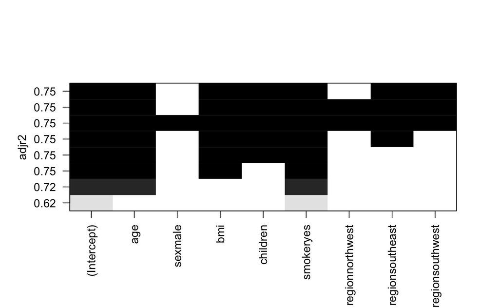

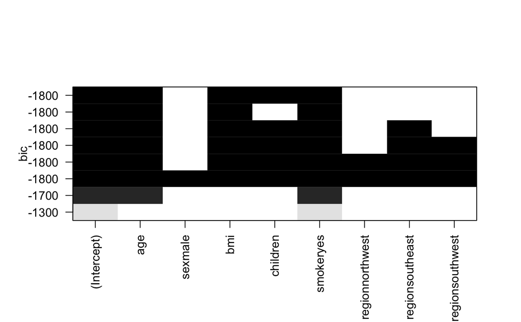

```r
null_model <- lm(charges ~ 1, data = insurance)
wellfit_model = lm(charges ~ age + bmi + children + smoker, data = insurance)
overfit_model = lm(charges ~ ., data = insurance)

BIC(wellfit_model) - BIC(null_model)
```

```
[1] -1824.432
```

null model = lm(charges ~ l) wellfit model = lm(charges ~ age + bmi + children + smoker)

bic(null_model) - bic(wellfit_model)

```r
BIC(overfit_model) - BIC(null_model)
```

```
[1] -1802.166
```

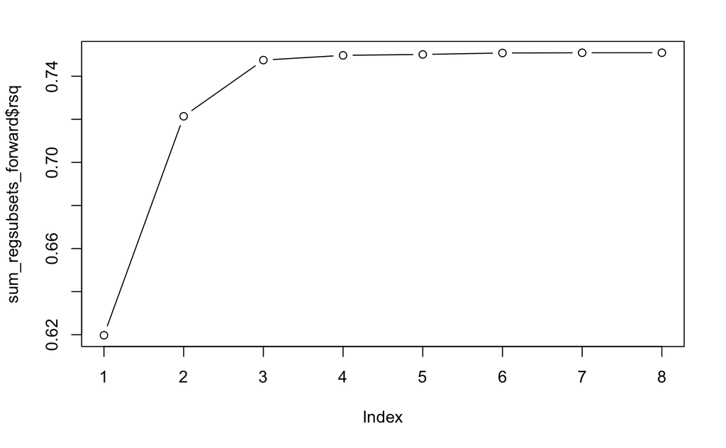

```r
plot(sum_regsubsets_forward$rsq, type = "b")
```

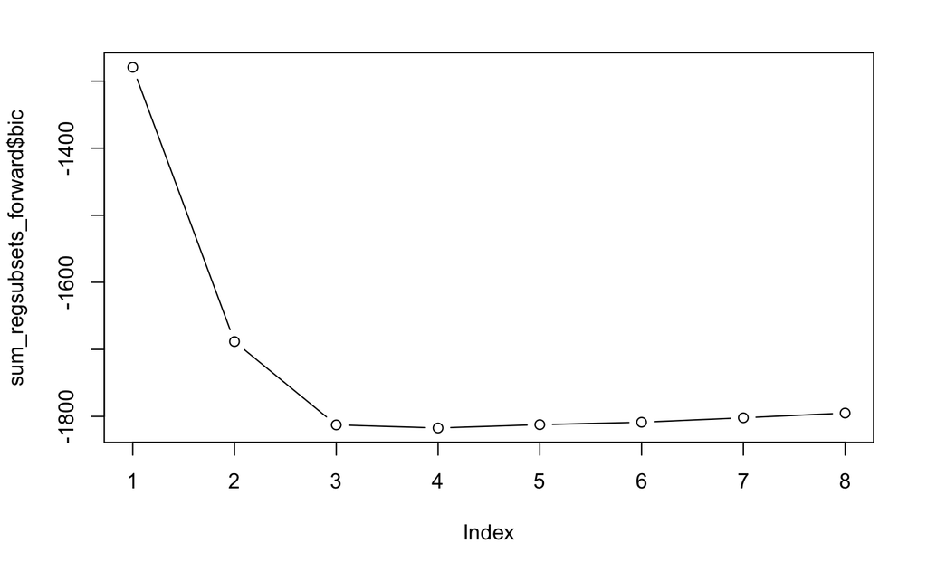

Task Re-run the analyses above using the backward selection and exhaustive search variable selection methods [Hint - look at the regsubsets() docs to see how to do this] Compare the tables (or plots, whichever you find easier) showing which predictors are included for forward selection, backward selection and exhaustive search. Do you find any differences? Use adjusted R-squared as your measure of fit.

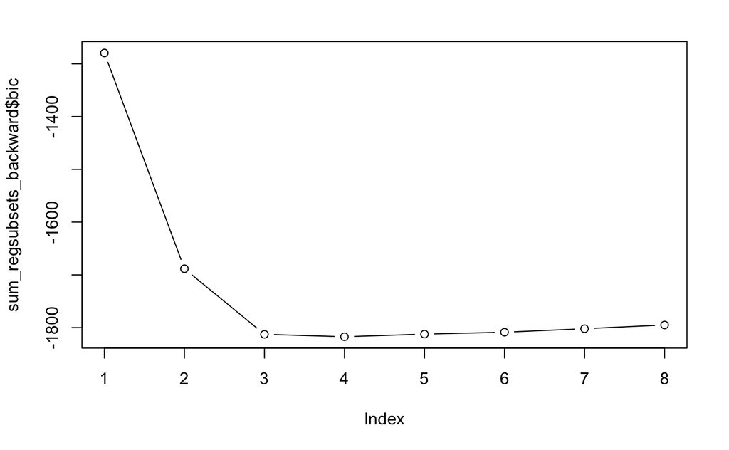

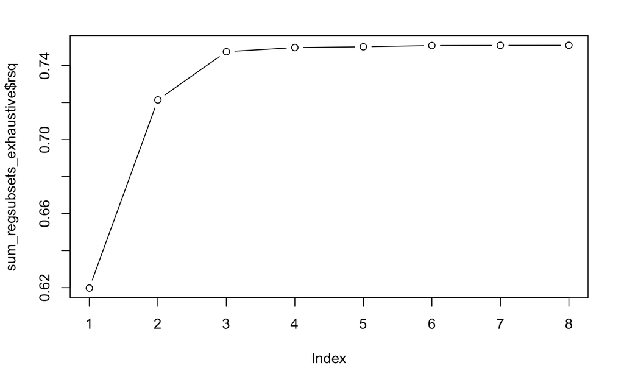

The automatic model didn’t check p values, so this is something we have to do manually

```r
summary(regsubsets_exhaustive)$which[6,]
```

```
    (Intercept)             age         sexmale             bmi        children       smokeryes regionnorthwest regionsoutheast
           TRUE            TRUE           FALSE            TRUE            TRUE            TRUE           FALSE            TRUE
regionsouthwest
           TRUE
```

```r
mod_without_region <- lm(charges ~ age + bmi + children + smoker, data = insurance)

summary(mod_without_region)
```

```
Call:
lm(formula = charges ~ age + bmi + children + smoker, data = insurance)

Residuals:
     Min       1Q   Median       3Q      Max
-11897.9  -2920.8   -986.6   1392.2  29509.6

Coefficients:
             Estimate Std. Error t value Pr(>|t|)
(Intercept) -12102.77     941.98 -12.848  < 2e-16 ***
age            257.85      11.90  21.675  < 2e-16 ***
bmi            321.85      27.38  11.756  < 2e-16 ***
children       473.50     137.79   3.436 0.000608 ***
smokeryes    23811.40     411.22  57.904  < 2e-16 ***
---
Signif. codes:  0 ‘***’ 0.001 ‘**’ 0.01 ‘*’ 0.05 ‘.’ 0.1 ‘ ’ 1

Residual standard error: 6068 on 1333 degrees of freedom
Multiple R-squared:  0.7497,    Adjusted R-squared:  0.7489
F-statistic: 998.1 on 4 and 1333 DF,  p-value: < 2.2e-16
```

```r
mod_with_region <- lm(charges ~ age + bmi + children + smoker + region,
                      data = insurance)
summary(mod_with_region)
```

```
Call:
lm(formula = charges ~ age + bmi + children + smoker + region,
    data = insurance)

Residuals:
     Min       1Q   Median       3Q      Max
-11367.2  -2835.4   -979.7   1361.9  29935.5

Coefficients:
                 Estimate Std. Error t value Pr(>|t|)
(Intercept)     -11990.27     978.76 -12.250  < 2e-16 ***
age                256.97      11.89  21.610  < 2e-16 ***
bmi                338.66      28.56  11.858  < 2e-16 ***
children           474.57     137.74   3.445 0.000588 ***
smokeryes        23836.30     411.86  57.875  < 2e-16 ***
regionnorthwest   -352.18     476.12  -0.740 0.459618
regionsoutheast  -1034.36     478.54  -2.162 0.030834 *
regionsouthwest   -959.37     477.78  -2.008 0.044846 *
---
Signif. codes:  0 ‘***’ 0.001 ‘**’ 0.01 ‘*’ 0.05 ‘.’ 0.1 ‘ ’ 1

Residual standard error: 6060 on 1330 degrees of freedom
Multiple R-squared:  0.7509,    Adjusted R-squared:  0.7496
F-statistic: 572.7 on 7 and 1330 DF,  p-value: < 2.2e-16
```

```r
anova(mod_with_region, mod_without_region)
```

```
Analysis of Variance Table

Model 1: charges ~ age + bmi + children + smoker + region
Model 2: charges ~ age + bmi + children + smoker
  Res.Df        RSS Df  Sum of Sq      F  Pr(>F)
1   1330 4.8845e+10
2   1333 4.9078e+10 -3 -233200844 2.1166 0.09631 .
---
Signif. codes:  0 ‘***’ 0.001 ‘**’ 0.01 ‘*’ 0.05 ‘.’ 0.1 ‘ ’ 1
```

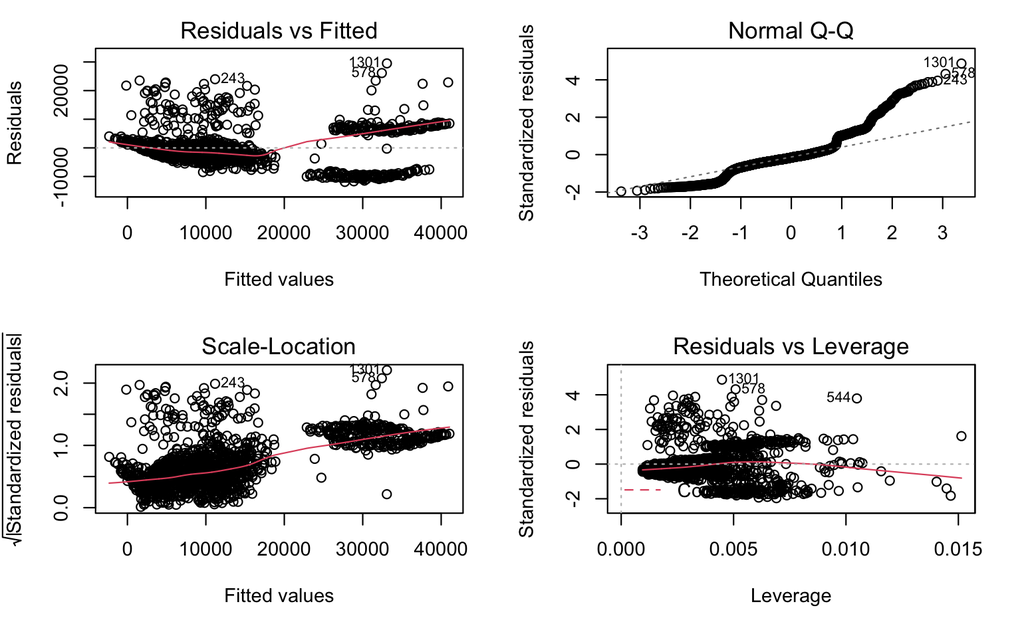

```r
par(mfrow = c(2, 2))
plot(mod_without_region)
```

This is not a good model, and because there are not many things we can change, we would have to ask for more data

Task Go ahead and extract the 4 -predictor model, and then check its significance and the diagnostic plots.

| age | sex | bmi | children | smoker | region | charges |
| --- | --- | --- | --- | --- | --- | --- |
| 19 | female | 27.900 | 0 | yes | southwest | 16884.924 |
| 18 | male | 33.770 | 1 | no | southeast | 1725.552 |
| 28 | male | 33.000 | 3 | no | southeast | 4449.462 |
| 33 | male | 22.705 | 0 | no | northwest | 21984.471 |
| 32 | male | 28.880 | 0 | no | northwest | 3866.855 |
| 31 | female | 25.740 | 0 | no | southeast | 3756.622 |
| 46 | female | 33.440 | 1 | no | southeast | 8240.590 |
| 37 | female | 27.740 | 3 | no | northwest | 7281.506 |
| 37 | male | 29.830 | 2 | no | northeast | 6406.411 |
| 60 | female | 25.840 | 0 | no | northwest | 28923.137 |

[output cut: 990 more lines]